# Final Exam - Data Analysis

Catherine Clemmons

2024-12-01

# Question 1: Fuji Apples

An agricultural research team in Idaho investigated the effect of Fuji apple trees’ branch configuration on the fruit produced by the trees. They planted 24 trees in an experimental orchard in three rows. Each row was treated to promote one of three branch configurations: “overlapping arm,” “tipped arm,” and “tall spindle.” Each of the treatments was applied to eight trees.

In the 2012 growing season, the trees’ fruit was harvested and the average weight per apple (grams) was recorded for each tree. The data are found in the file `fuji_apples.csv`.

**Key question:** Do the data suggest that the branch configuration affects the fruit weights?

## Descriptive Analysis

The distribution of apple weights for each branch configuration, as shown in the boxplot below, indicates that the `tall_spindle` configuration has highest fruit weights with a mean weight of 276.73g and a median of 294.76g. The `overlapped_arm` configuration has the smallest fruit weights with mean and median weights of 181.79g and 184.23g respectively. The `tipped_arm` configuration lies in the middle, closer to the `tall_spindle` group, with a mean weight of 239.98g and median weight of 248.01g. The spread of weights within each group followes a similar trend: the `tall_spindle` configuration has the largest interquartile range (IQR) of 99.04g, the `overlapped_arm` group has the smallest IQR (32.12g), and the `tipped_arm` group is intermediate with an IQR of 57.80g. There are no outliers of apple weight observed within any of the branch configuration groups.

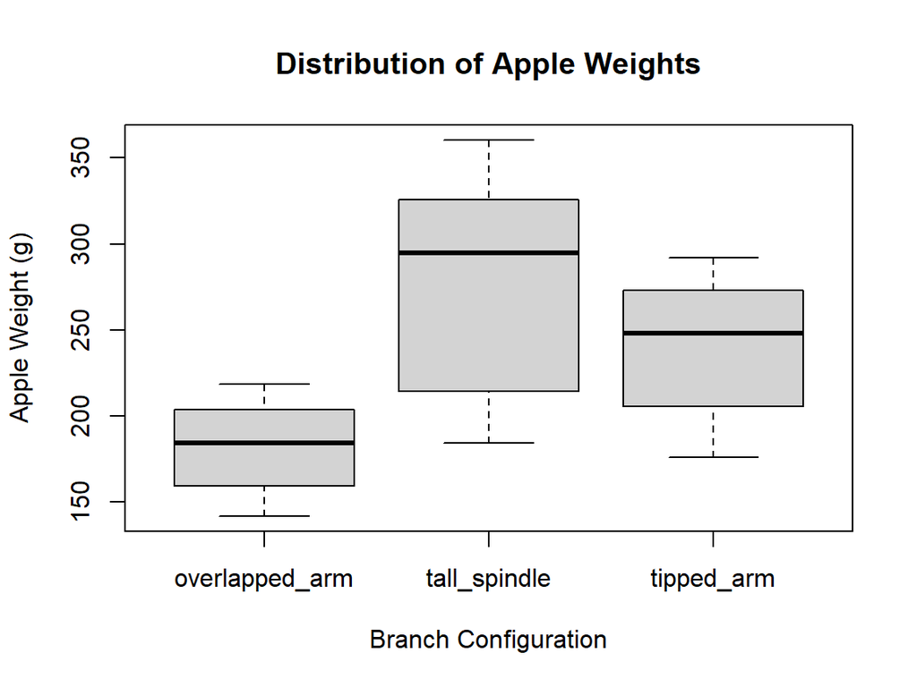

**Summary Statistics of Apple Weights**

```
##                    Min.  1st Qu.   Median     Mean  3rd Qu.     Max.
## overlapped_arm 141.6637 167.5722 184.2324 181.7864 199.6957 218.2755
## tall_spindle   183.9594 223.4304 294.7569 276.7257 322.4663 360.4536
## tipped_arm     175.6309 207.4618 248.0069 239.9840 265.2623 291.8116
```

## Inferential Analysis

To determine if the observed differences in average fruit weight are statistically significant, an ANOVA test was performed using a selected $\alpha = 0.05$ significance level. The hypotheses for the test are:

$H_0: \mu_{overlapped}=\mu_{tall} =\mu_{tipped};$  
$H_A:$ Not all mean apple weights are equal

The calculated test statistic is $f_0=8.0712$, with a p-value of 0.00251. Therefore, $H_0$ is rejected in favor of the alternative hypothesis, indicating that there is evidence of a statistically significant difference in mean apple weights among the branch configurations.

## Conclusion

The analysis indicates a statistically significant difference in the mean apple weights across the three branch configurations. The `tall_spindle` configuration appears to have the highest average apple weights, while the `overlapped_arm` has the lowest. However, additional analysis is needed to determine which of the differences between individual pairs of branch configurations are significant. For further exploration, a Tukey test could be conducted to evaluate all pairwise comparisons and identify which groups differ significantly.

The ANOVA test assumes normality of residuals and equality of variances. The normal Q-Q Plot of residuals, provided below, suggests slight deviations from normality, particularly in the middle and upper right of the plot. Furthermore, the residuals-by-group plot below indicates potential volations of the equal variance assumption, as the `tall_spindle` group exhibits the highest variance while the `overlapped_arm` group has the lowest. To address these issues in further analysis, a transformation of the data could be applied to better meet ANOVA assumptions and ensure robustness of the analysis.

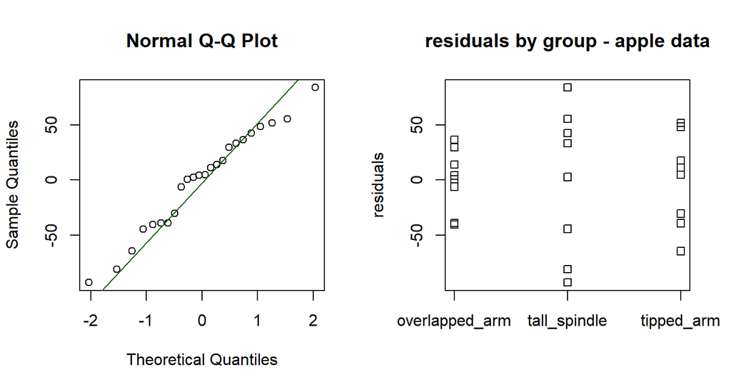

The ANOVA test also assumes independence of observations. In the experiment design, each row of the orchard was assigned a specific branch configuration. This design could introduce systematic bias, as environmental factors such as sunlight, irrigation, or soil composition could vary between the rows, potentially violating the independence assumption. The experiment design could be improved by randomly assigning the branch configurations among the 24 trees tested. Additionally, the study was conducted at a single location in Idaho using one type of apple tree, limiting the generalization of the findings to other locations or apple varieties.

# Question 2: Maryland Vehicle Crashes

The dataset `maryland_crash.csv` contains records of vehicle crashes in Montgomery County, Maryland for which police reports were filed between 2015 and 2023. The posted data reflects a subset of all crashes: those that occurred during rain, snow, or sleet.

A team of government officials is looking to better understand conditions under which serious traffic accidents occur. One question they are interested in is whether the type of precipitation is related to increased chance of injury. This question is related to the variables `Weather` and `Injury.Severity`.

**Key question:** Do the data suggest that the weather condition is associated with injury severity? Under which condition(s) are crashes more likely to occur?

## Descriptive Analysis

The dataset contains 639 observations of vehicle crashes in Montgomery County, Maryland occurring during rainy, snowy, or sleet conditions. Of these, 568 crashes (88.89%) occurred during rain, 42 (6.57%) occurred during snow, and 29 (4.54%) occurred during sleet.

Examining the bar plot, below, of the proportion of severe accidents (those with suspected injuries) by weather condition, it is notable that sleet conditions had the highest proportion of severe accidents, with 27.59% of crashes having suspected injuries. Snowy weather had the lowest proportion, at 11.90%, while rainy conditions fell in between, with 18.84% of accidents classified as severe. Despite the higher number of accidents occurring in rainy condition, sleet appears to be associated with more sever accidents.

Looking at the proportions of weather conditions by accident type, provided in a bar plot below, the majority of accidents with no apparent injury (88.82%) occurred during rainy conditions, while a smaller proportion occurred during sleet (4.05%) and snow (7.13%). For more severe accidents, the distribution shifted, with sleet accounting for 6.67% of these accidents, slightly more than snow, which had 4.17%. The proportions for rain remained fairly consistent, with 89.17% of suspected injury accidents occuring during rainy conditions.

**Observed Counts**

```
##
##           NO APPARENT INJURY SUSPECTED INJURY
##   RAINING                461              107
##   SLEET                   21                8
##   SNOW                    37                5
```

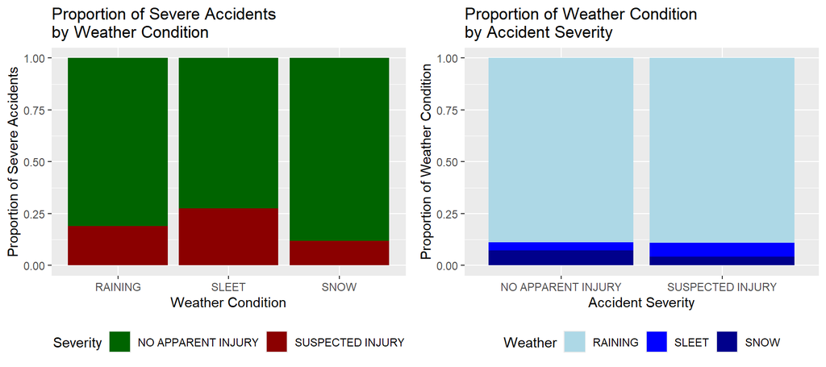

## Inferential Analysis

A Chi-square test was completed to determine if there is a statistically significant association between weather conditions and accident severity. The significance level was set at $\alpha=0.1$, and the hypotheses were:

$H_0:$ weather condition and accident severity are independent  
$H_A:$ weather condition and accident severity are associated (not independent)

The calculated $\chi^2_0$ test statistic is 2.7773 and the p-value is 0.2494. Since the p-value is greater than the selected $\alpha$, we fail to reject the null hypothesis. There is insufficient evidence to conclude a statistically significant association between weather condition and crash severity.

## Conclusion

While sleet conditions have a higher proportion of crashes with suspected injuries compared to the other weather conditions, the data does not provide evidence of a statistically significant association between accident severity and weather conditions. Additionaly, although most crashes occured during rainy conditions, we cannot conclude that accidents are more likely to occur under rainy conditions compared to snow or sleet. It is possible that in Montgomery County, Maryland there are simply more rainy days than sleet or snowy days, which explains the greater number of crashes during rain. To answer this question more conclusively, additional information on the distribution of weather types and crash frequencies would be necessary.

The Chi-square test used in this analysis is a large sample test, which is most appropriate when the expected count for each group is at least 5. Given the small sample sizes for sleet and snow conditions, it is important to verify the expected counts. The expected counts are provided in the table below, and the smallest expected count is 5.446 (for crashes with suspected injury under sleet conditions), so the large sample assumption of the Chi-square test is not violated.

**Expected Counts**

```
##
##           NO APPARENT INJURY SUSPECTED INJURY
##   RAINING          461.33333       106.666667
##   SLEET             23.55399         5.446009
##   SNOW              34.11268         7.887324
```

While the analysis did not reveal a significant association, other factors (such as road conditions, traffic volume, time of day, etc.) might influence the severity of accidents but were not examined here. Additionally, this study could be impacted by the categorization of variables. Weather conditions are complex, and mixed precipitation is common, so the three categories used here may be an oversimplification. Similarly, the dataset only includes an indicator of suspected injury, which does not capture the full spectrum of injuries, from minor to severe or fatal, which may limit the conclusions that can be drawn about the true impact of weather conditions on accident severity.

Furthermore, the dataset is limited to crashes for which policy reports were filed, which could introduce reporting bias. Crashes with suspected injuries may be more likely to be reported, potentially violating the assumption of independence of observations. Lastly, this data set is specific to Montgomery County, Maryland, and to crashes that occurred between 2015 to 2023. Therefore, the findings may not be generalizable to other regions or time periods where weather conditions or driving patterns may differ.